# Where’s the Best Breakfast in New Orleans?

- Show All Code
- Hide All Code
- View Source

7 million Yelp reviews, three ways to divide a city, and a rating that adjusts for easy and tough reviewers

If you only have one morning in New Orleans, head **just outside downtown**. **Bywater & St. Roch (ZIP 70117)** is the best area overall, **Mid-City (70119)** has the most top-10 spots, and the top-ranked spot is **Swiss Confectionery**. Downtown has the most choice, but not the best choice.

Best area

Bywater& St. Roch, ZIP 70117

Most top-10 spots

Mid-City4 of the top 10, ZIP 70119

Number 1 spot

Swiss ConfectioneryOrleans Ave, Mid-City

Restaurants studied

575with 159,552 reviews

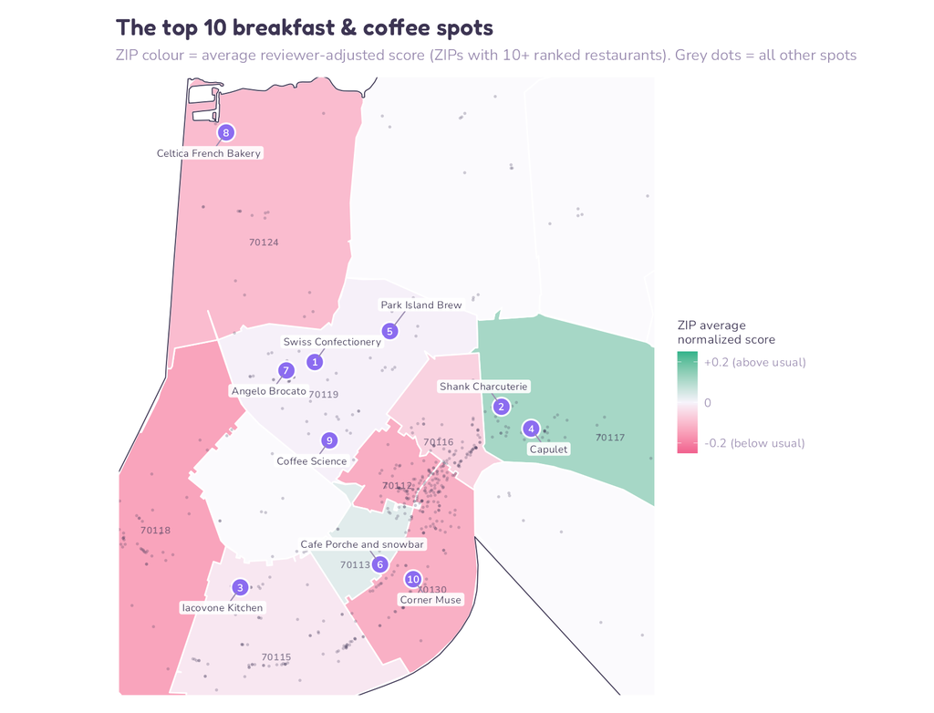

## 1 The question

New Orleans is famous for its breakfasts: beignets, brunch and chicory coffee. But with one morning to spare, **where should you go?**

> **Where can someone find the best breakfast and coffee in New Orleans, and which area of the city is best for finding it?**

A plain star average has two problems. Some restaurants have only a handful of reviews, and some reviewers give everything five stars while others almost never do. So in this project, “best” means:

1. **Rated well by reviewers who are hard to impress.** Each review is compared with that reviewer’s own usual rating (the *adjusted score*).
2. **Enough evidence.** A restaurant needs at least 10 reviews from active reviewers to be ranked.
3. **For areas:** lots of good options, and restaurants that are rated above reviewers’ usual more often than not.

## 2 The data, and how the huge files were handled

The project uses two files from the [Yelp Open Dataset](https://business.yelp.com/data/resources/open-dataset/): the **business file** (113 MB, 150,346 businesses) and the **review file** (**5.1 GB, 6,990,280 reviews**, from 2005 to January 2022).

The review file is bigger than a laptop’s memory can comfortably hold. So instead of opening it all at once, the code reads it **100,000 reviews at a time**, keeps only the reviews of New Orleans restaurants, and throws the rest away before reading the next batch.

- **Streaming import.** Both files are read with `jsonlite::stream_in()` and a handler function. Each batch is cut down to the needed columns before the next is read. Scanning all 7 million reviews took about **6 minutes**.
- **Only what’s needed.** Only the business and review files are pulled out of the Yelp archive.
- **Small, compressed outputs.** Results are saved as `xz`-compressed `.rds` files. Review text is stored separately: the review table without text is 15 MB, the text alone 71 MB.
- **Raw files stay local.** The raw JSON files are several gigabytes, more than GitHub allows, so they are listed in `.gitignore` and can be deleted once the `.rds` files are saved.

**Problems along the way, and how they were solved.**

- **The download was huge and slow.** The Yelp archive (`Yelp-JSON.zip`) is about 4 GB, and downloading it took a long time. To avoid repeating that, the archive was downloaded **once** into `data/raw/`. The import script takes only the two JSON files it needs out of the archive, and skips that step if they are already there.
- **The review file is too big to open at once.** Reading the 5.1 GB file in one go would need more memory than a laptop comfortably has. Reading it in 100,000-review batches keeps memory use small. If a computer still runs short, `page_size` at the top of `R/import.R` can be lowered.
- **Keeping the raw files around costs disk space.** Once the filtered `.rds` files (about 87 MB in total) were saved and read back, the multi-gigabyte raw files were no longer needed for the rest of the analysis. `R/import.R` can delete them by setting `delete_raw_files <- TRUE`.

**Show the code: R/import.R**

```r
# =============================================================================
# R/import.R
# Yelp Open Dataset -> New Orleans restaurants + their reviews (compressed RDS)
#
# Run from the project root (the folder that contains README.md):
#   Rscript R/import.R
# or open the project in RStudio and source("R/import.R").
#
# Input  (put ONE of these in data/raw/):
#   - Yelp-JSON.zip                        (the file Yelp gives you), or
#   - yelp_dataset.tar                     (what is inside the zip), or
#   - yelp_academic_dataset_business.json  and
#     yelp_academic_dataset_review.json    (already extracted)
#
# Output (data/new_orleans/):
#   - business_new_orleans.rds      New Orleans restaurants (one row per business)
#   - reviews_new_orleans.rds       every review of those restaurants, no text
#   - review_text_new_orleans.rds   review_id + text (kept separate: large file)
#   - import_log.txt                row counts, timings, file sizes
#
# Design notes (for the "large-data management" section of the report):
#   * Both JSON files are read with jsonlite::stream_in() and a handler, so only
#     one page of records is in memory at a time. Each page is reduced to the
#     needed columns (and, for reviews, to New Orleans restaurants) before the
#     next page is read. The ~5 GB review file never has to fit in RAM.
#   * Only the two needed JSON files are pulled out of the tar archive.
#   * Outputs are saved with xz compression.
# =============================================================================

suppressPackageStartupMessages({
  library(jsonlite)
  library(dplyr)
  library(stringr)
})

# ---- Settings ---------------------------------------------------------------

raw_dir <- "data/raw"
out_dir <- "data/new_orleans"

# Set to TRUE to delete the raw JSON / tar / zip files after the RDS files have
# been written and successfully read back. Leave FALSE until you are sure.
delete_raw_files <- FALSE

# Records read per page. Lower it (e.g. 25000) if your computer runs out of memory.
page_size <- 1e5

business_file <- file.path(raw_dir, "yelp_academic_dataset_business.json")
review_file   <- file.path(raw_dir, "yelp_academic_dataset_review.json")

dir.create(raw_dir, recursive = TRUE, showWarnings = FALSE)
dir.create(out_dir, recursive = TRUE, showWarnings = FALSE)

log_lines <- character()
log_msg <- function(...) {
  line <- paste0(format(Sys.time(), "%H:%M:%S"), "  ", paste0(...))
  message(line)
  log_lines <<- c(log_lines, line)
}
fmt <- function(x) format(x, big.mark = ",", scientific = FALSE)
mb <- function(path) sprintf("%.1f MB", file.size(path) / 1024^2)

# ---- Step 1: unzip / untar (only if the JSON files are not there yet) -------

needed_json <- basename(c(business_file, review_file))

if (!all(file.exists(c(business_file, review_file)))) {

  tar_file <- list.files(raw_dir, pattern = "\\.tar$", full.names = TRUE,
                         recursive = TRUE)[1]

  if (is.na(tar_file)) {
    zip_file <- list.files(raw_dir, pattern = "\\.zip$", full.names = TRUE)[1]
    if (is.na(zip_file)) {
      stop("No Yelp files found in ", raw_dir, ". See README.md for download steps.")
    }
    log_msg("Unzipping ", basename(zip_file), " (", mb(zip_file), ")")
    zip_members <- unzip(zip_file, list = TRUE)$Name
    tar_member  <- grep("\\.tar$", zip_members, value = TRUE)[1]
    if (is.na(tar_member)) {
      # Some copies of the zip hold the JSON files directly
      json_members <- zip_members[basename(zip_members) %in% needed_json]
      unzip(zip_file, files = json_members, exdir = raw_dir, junkpaths = TRUE)
    } else {
      unzip(zip_file, files = tar_member, exdir = raw_dir, junkpaths = TRUE)
      tar_file <- file.path(raw_dir, basename(tar_member))
    }
  }

  if (!is.na(tar_file) && file.exists(tar_file)) {
    log_msg("Extracting business + review JSON from ", basename(tar_file),
            " (", mb(tar_file), ")")
    tar_members  <- untar(tar_file, list = TRUE)
    json_members <- tar_members[basename(tar_members) %in% needed_json]
    untar(tar_file, files = json_members, exdir = raw_dir)
    # Move to data/raw/ in case the tar stores them inside a sub-folder
    for (m in json_members) {
      from <- file.path(raw_dir, m)
      to   <- file.path(raw_dir, basename(m))
      if (normalizePath(from) != normalizePath(to, mustWork = FALSE)) file.rename(from, to)
    }
  }

  if (!all(file.exists(c(business_file, review_file)))) {
    stop("Could not find both JSON files after extraction. Check ", raw_dir, ".")
  }
}

log_msg("Business JSON: ", mb(business_file), " | Review JSON: ", mb(review_file))

# Helper: keep the listed columns from a page, adding any that are missing
keep_cols <- function(df, cols) {
  for (col in setdiff(cols, names(df))) df[[col]] <- NA
  df[, cols, drop = FALSE]
}

# ---- Step 2: import businesses (streamed) -----------------------------------

business_cols <- c("business_id", "name", "address", "city", "state",
                   "postal_code", "latitude", "longitude", "stars",
                   "review_count", "categories")

t0 <- Sys.time()
business_pages <- list()
business_total <- 0

stream_in(
  file(business_file),
  handler = function(df) {
    business_total <<- business_total + nrow(df)
    df <- keep_cols(df, business_cols)
    # Keep Louisiana only at this stage; New Orleans is decided below
    business_pages[[length(business_pages) + 1]] <<- df[df$state %in% "LA", ]
  },
  pagesize = page_size,
  verbose = FALSE
)

business_la <- bind_rows(business_pages)
rm(business_pages); invisible(gc())

log_msg("Businesses read: ", fmt(business_total),
        " | in Louisiana: ", fmt(nrow(business_la)),
        " | ", round(difftime(Sys.time(), t0, units = "secs")), " s")

# ---- Step 3: filter to New Orleans restaurants ------------------------------

# How is "New Orleans" spelled in the city field? (useful for the report)
city_spellings <- business_la |>
  filter(str_detect(str_to_lower(city), "new\\s*orleans")) |>
  count(city, sort = TRUE)
message("\nCity labels containing 'New Orleans':")
print(as.data.frame(city_spellings), row.names = FALSE)

new_orleans_restaurants <- business_la |>
  filter(
    state == "LA",
    str_to_lower(str_squish(city)) == "new orleans",
    !is.na(categories),
    str_detect(categories, regex("Restaurants", ignore_case = TRUE))
  ) |>
  mutate(
    city          = str_squish(city),
    postal_code   = na_if(postal_code, ""),
    categories    = str_squish(categories),
    business_name = str_squish(name)
  ) |>
  distinct(business_id, .keep_all = TRUE)

rm(business_la); invisible(gc())

log_msg("New Orleans restaurants: ",
        fmt(nrow(new_orleans_restaurants)))

print(
  new_orleans_restaurants |>
    summarise(
      number_of_restaurants = n(),
      missing_latitude   = sum(is.na(latitude)),
      missing_longitude  = sum(is.na(longitude)),
      missing_categories = sum(is.na(categories)),
      missing_postal     = sum(is.na(postal_code))
    )
)

# ---- Step 4: import reviews for those restaurants only (streamed) -----------

review_cols <- c("review_id", "business_id", "user_id", "stars", "date",
                 "text", "useful", "funny", "cool")
nola_ids <- new_orleans_restaurants$business_id

t0 <- Sys.time()
review_pages <- list()
review_total <- 0

stream_in(
  file(review_file),
  handler = function(df) {
    review_total <<- review_total + nrow(df)
    df <- df[df$business_id %in% nola_ids, , drop = FALSE]
    if (nrow(df) > 0) {
      review_pages[[length(review_pages) + 1]] <<- keep_cols(df, review_cols)
    }
    if (review_total %% 1e6 < page_size) {
      message("  ...", fmt(review_total), " reviews scanned")
    }
  },
  pagesize = page_size,
  verbose = FALSE
)

reviews_all_cols <- bind_rows(review_pages)
rm(review_pages); invisible(gc())

log_msg("Reviews scanned: ", fmt(review_total),
        " | kept for New Orleans restaurants: ",
        fmt(nrow(reviews_all_cols)),
        " | ", round(difftime(Sys.time(), t0, units = "mins"), 1), " min")

# Split the review text off: it is most of the file size and is not needed for
# the ratings analysis. review_id links the two tables if you need the text.
new_orleans_reviews <- reviews_all_cols |> select(-text)
new_orleans_review_text <- reviews_all_cols |> select(review_id, business_id, text)
rm(reviews_all_cols); invisible(gc())

# ---- Step 5: save as compressed RDS and verify ------------------------------

out_business <- file.path(out_dir, "business_new_orleans.rds")
out_reviews  <- file.path(out_dir, "reviews_new_orleans.rds")
out_text     <- file.path(out_dir, "review_text_new_orleans.rds")

saveRDS(new_orleans_restaurants, out_business, compress = "xz")
saveRDS(new_orleans_reviews,     out_reviews,  compress = "xz")
saveRDS(new_orleans_review_text, out_text,     compress = "xz")

check_business <- readRDS(out_business)
check_reviews  <- readRDS(out_reviews)
check_text     <- readRDS(out_text)
stopifnot(
  identical(dim(check_business), dim(new_orleans_restaurants)),
  identical(dim(check_reviews),  dim(new_orleans_reviews)),
  identical(dim(check_text),     dim(new_orleans_review_text))
)

log_msg("Saved ", basename(out_business), " (", mb(out_business), "), ",
        basename(out_reviews), " (", mb(out_reviews), "), ",
        basename(out_text), " (", mb(out_text), ")")

if (file.size(out_text) > 95 * 1024^2) {
  log_msg("NOTE: ", basename(out_text), " is over GitHub's 100 MB limit; ",
          "it is listed in .gitignore and stays on your computer.")
}

message("\nglimpse(business):"); glimpse(new_orleans_restaurants)
message("\nglimpse(reviews):");  glimpse(new_orleans_reviews)

# ---- Step 6: optionally delete the raw files --------------------------------

if (delete_raw_files) {
  raw_files <- list.files(raw_dir, pattern = "\\.(json|tar|zip)$",
                          full.names = TRUE, recursive = TRUE)
  freed <- sum(file.size(raw_files)) / 1024^3
  file.remove(raw_files)
  log_msg("Deleted ", length(raw_files), " raw files, freed ",
          sprintf("%.1f GB", freed))
}

writeLines(log_lines, file.path(out_dir, "import_log.txt"))
message("\nDone. Load the data later with:\n",
        "  new_orleans_restaurants <- readRDS(\"", out_business, "\")\n",
        "  new_orleans_reviews     <- readRDS(\"", out_reviews, "\")")
```

## 3 Choosing the restaurants

**New Orleans restaurants.** A business counts if `state` is `LA`, its `city` is “New Orleans”, and its categories include “Restaurants”. That gives **2,261 restaurants**.

**Missing values.** None of the 2,261 restaurants is missing a latitude, longitude, category list or star rating, so none had to be dropped. One has a blank postal code (recoded to `NA`) and 39 have a blank street address. Neither matters here, because each restaurant is placed in an area from its coordinates with a spatial join, not from its postal code. Among the 575 breakfast & coffee restaurants, none is missing a postal code and 2 have a blank address. All 159,552 of their reviews have a star rating, date, reviewer ID and business ID.

**Breakfast & coffee.** Four categories describe places you’d go for a morning meal or a coffee break: *Breakfast & Brunch*, *Coffee & Tea*, *Cafes* and *Bakeries*.

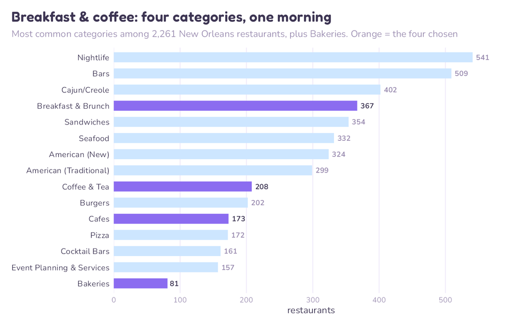

These four belong together because they often appear on the **same** restaurant:

| Category pair | Restaurants with both |
| --- | --- |
| Breakfast & Brunch + Coffee & Tea | 85 |
| Cafes + Coffee & Tea | 75 |
| Breakfast & Brunch + Cafes | 65 |
| Bakeries + Coffee & Tea | 37 |
| Bakeries + Breakfast & Brunch | 32 |
| Bakeries + Cafes | 16 |

A restaurant is included if it has **at least one** of the four categories. That gives **575 restaurants** spread over 24 ZIP code areas, far more than the required 10 restaurants in 7 areas. Their **159,552 reviews**, from 97,950 different reviewers, were pulled out before any further analysis.

**Show the code: R/clean.R**

```r
# =============================================================================
# R/clean.R
# Step 3: select a related category group (breakfast & coffee)
# Step 4: join businesses to reviews for just that category group
#
# Run from the project root, after R/import.R:
#   Rscript R/clean.R
# =============================================================================

suppressPackageStartupMessages({
  library(dplyr)
  library(stringr)
  library(tidyr)
})

business <- readRDS("data/new_orleans/business_new_orleans.rds")
reviews  <- readRDS("data/new_orleans/reviews_new_orleans.rds")

dir.create("data/new_orleans", showWarnings = FALSE, recursive = TRUE)

# ---- Step 3: category selection --------------------------------------------

# One row per business-category combination, cleaned up.
restaurant_categories <- business |>
  select(business_id, categories) |>
  separate_rows(categories, sep = ",") |>
  mutate(category = str_squish(categories)) |>
  select(business_id, category)

category_counts <- restaurant_categories |>
  count(category, sort = TRUE)

write.csv(category_counts, "data/new_orleans/category_counts.csv", row.names = FALSE)

# Theme: breakfast & coffee. These four categories are all places New Orleans
# residents/visitors go for a morning meal or a coffee break, so they support
# one focused question: "Where can someone find the best breakfast and coffee
# in New Orleans, and which area is best for finding it?"
selected_categories <- c("Breakfast & Brunch", "Coffee & Tea", "Cafes", "Bakeries")

# Co-occurrence among the selected categories (how often they overlap on the
# same business) -- evidence that they form one coherent group rather than
# four unrelated ones.
category_pairs <- restaurant_categories |>
  filter(category %in% selected_categories) |>
  inner_join(
    restaurant_categories |> filter(category %in% selected_categories),
    by = "business_id",
    relationship = "many-to-many"
  ) |>
  filter(category.x < category.y) |>
  count(category.x, category.y, sort = TRUE)

message("Category counts for the selected group:")
print(category_counts |> filter(category %in% selected_categories))
message("\nCo-occurrence between selected categories:")
print(category_pairs)

# Inclusion rule: a restaurant qualifies if it has AT LEAST ONE of the four
# selected categories.
selected_restaurant_ids <- restaurant_categories |>
  filter(category %in% selected_categories) |>
  distinct(business_id) |>
  pull(business_id)

selected_restaurants <- business |>
  filter(business_id %in% selected_restaurant_ids)

n_areas <- n_distinct(selected_restaurants$postal_code, na.rm = TRUE)

message(
  "\nQualifying restaurants: ", nrow(selected_restaurants),
  " across ", n_areas, " ZIP codes (requirement: >= 10 restaurants, >= 7 areas)"
)
stopifnot(nrow(selected_restaurants) >= 10, n_areas >= 7)

saveRDS(selected_restaurants, "data/new_orleans/selected_restaurants.rds")

# ---- Step 4: join reviews to the selected restaurants only -----------------

selected_reviews <- reviews |>
  semi_join(selected_restaurants, by = "business_id")

message(
  "\nReviews for selected (breakfast & coffee) restaurants: ",
  nrow(selected_reviews), " out of ", nrow(reviews), " total New Orleans reviews"
)

saveRDS(selected_reviews, "data/new_orleans/selected_reviews.rds")

message("\nSaved data/new_orleans/selected_restaurants.rds, selected_reviews.rds, category_counts.csv")
```

## 4 Checking the city boundary

Yelp’s `city` field is just text typed by the business. To check it, each restaurant’s latitude and longitude were matched to the official city boundary from the U.S. Census with a spatial join.

| Yelp city | Official place | Restaurants |
| --- | --- | --- |
| New Orleans | New Orleans | 564 |
| New Orleans | Elmwood | 2 |
| New Orleans | Harahan | 2 |
| New Orleans | Jefferson | 2 |
| New Orleans | Metairie | 2 |
| New Orleans | Terrytown | 2 |
| New Orleans | Kenner | 1 |

11 restaurants have a New Orleans mailing address but sit just outside the city limits, in Jefferson Parish. They are real nearby options, so they stay in.

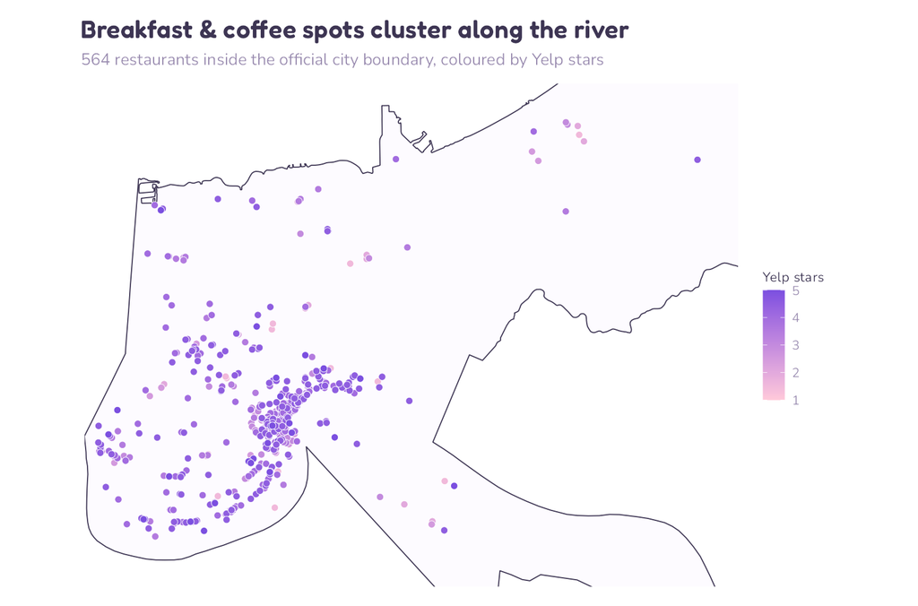

**Show the code: R/analysis.R**

```r
# =============================================================================
# R/analysis.R
# Step 5: spatial join to an official city boundary (tigris::places)
# Step 6: compare two geographic systems (ZCTA vs. Census tract) and pick one
#
# Run from the project root, after R/clean.R:
#   Rscript R/analysis.R
# =============================================================================

suppressPackageStartupMessages({
  library(dplyr)
  library(sf)
  library(tigris)
  library(ggplot2)
  library(viridis)
})

options(tigris_use_cache = TRUE)
dir.create("figures", showWarnings = FALSE, recursive = TRUE)

selected_restaurants <- readRDS("data/new_orleans/selected_restaurants.rds")

restaurant_points <- selected_restaurants |>
  filter(!is.na(longitude), !is.na(latitude)) |>
  st_as_sf(coords = c("longitude", "latitude"), crs = 4326, remove = FALSE)

# ---- Step 5: spatial join to the official New Orleans place boundary -------

louisiana_places <- tigris::places(state = "LA", cb = TRUE, year = 2024, class = "sf") |>
  st_transform(4326)

restaurants_with_place <- restaurant_points |>
  st_join(
    louisiana_places |> select(GEOID, place_name = NAME),
    join = st_within,
    left = TRUE
  )

message("Yelp city label vs. official place boundary:")
city_vs_place <- restaurants_with_place |>
  st_drop_geometry() |>
  count(city, place_name, sort = TRUE)
print(as.data.frame(head(city_vs_place, 15)))

new_orleans_boundary <- louisiana_places |> filter(NAME == "New Orleans")
new_orleans_map_data <- restaurants_with_place |> filter(place_name == "New Orleans")

p_boundary <- ggplot() +
  geom_sf(data = new_orleans_boundary, fill = "grey95", color = "grey35") +
  geom_sf(data = new_orleans_map_data, aes(color = stars), alpha = 0.7, size = 1.5) +
  scale_color_viridis_c(option = "C", limits = c(1, 5)) +
  labs(
    title = "Breakfast & Coffee Spots Within the New Orleans City Boundary",
    color = "Business\nstars"
  ) +
  theme_minimal()

ggsave("figures/new_orleans_boundary_map.png", p_boundary, width = 7, height = 6, dpi = 150)

# ---- Step 6: compare two geographic systems ---------------------------------

# System 1: ZIP Code Tabulation Areas (ZCTA)
zctas_la <- tigris::zctas(state = "LA", cb = FALSE, year = 2010, class = "sf") |>
  select(area_id = ZCTA5CE10) |>
  st_transform(4326)

restaurants_by_zcta <- restaurant_points |>
  st_join(zctas_la, join = st_within, left = TRUE)

zcta_summary <- restaurants_by_zcta |>
  st_drop_geometry() |>
  group_by(area_id) |>
  summarise(
    number_of_restaurants = n(),
    average_business_stars = mean(stars, na.rm = TRUE),
    .groups = "drop"
  ) |>
  arrange(desc(number_of_restaurants))

# System 2: Census tracts (Orleans Parish)
tracts_orleans <- tigris::tracts(state = "LA", county = "Orleans", cb = TRUE, year = 2024, class = "sf") |>
  select(area_id = TRACTCE) |>
  st_transform(4326)

restaurants_by_tract <- restaurant_points |>
  st_join(tracts_orleans, join = st_within, left = TRUE)

tract_summary <- restaurants_by_tract |>
  st_drop_geometry() |>
  group_by(area_id) |>
  summarise(
    number_of_restaurants = n(),
    average_business_stars = mean(stars, na.rm = TRUE),
    .groups = "drop"
  ) |>
  arrange(desc(number_of_restaurants))

summarise_system <- function(df, label, n_areas_total) {
  matched <- df |> filter(!is.na(area_id))
  unmatched_n <- sum(is.na(df$area_id))
  tibble(
    geographic_system = label,
    number_of_areas = n_distinct(matched$area_id),
    restaurants_assigned = nrow(matched),
    unmatched_restaurants = unmatched_n,
    smallest_area_count = min(matched |> count(area_id) |> pull(n)),
    largest_area_count = max(matched |> count(area_id) |> pull(n))
  )
}

geographic_comparison <- bind_rows(
  summarise_system(st_drop_geometry(restaurants_by_zcta), "ZIP/ZCTA"),
  summarise_system(st_drop_geometry(restaurants_by_tract), "Census tract")
)

message("\nGeographic system comparison:")
print(as.data.frame(geographic_comparison))

write.csv(geographic_comparison, "data/new_orleans/geographic_comparison.csv", row.names = FALSE)
saveRDS(zcta_summary, "data/new_orleans/zcta_summary.rds")
saveRDS(tract_summary, "data/new_orleans/tract_summary.rds")

# Map of restaurant counts per ZCTA (the system this project selects -- see
# README for the justification).
zcta_map_data <- zctas_la |> left_join(zcta_summary, by = "area_id")

p_zcta <- ggplot() +
  geom_sf(data = zcta_map_data, aes(fill = number_of_restaurants), color = "white", size = 0.1) +
  geom_sf(data = new_orleans_boundary, fill = NA, color = "black", linewidth = 0.6) +
  coord_sf(xlim = st_bbox(new_orleans_boundary)[c("xmin", "xmax")],
           ylim = st_bbox(new_orleans_boundary)[c("ymin", "ymax")]) +
  scale_fill_viridis_c(option = "C", na.value = "grey90") +
  labs(
    title = "Breakfast & Coffee Restaurants per ZIP Code (ZCTA)",
    fill = "Restaurant\ncount"
  ) +
  theme_minimal()

ggsave("figures/zcta_restaurant_count_map.png", p_zcta, width = 7, height = 6, dpi = 150)

message("\nSaved figures/new_orleans_boundary_map.png, figures/zcta_restaurant_count_map.png")
message("Saved data/new_orleans/geographic_comparison.csv, zcta_summary.rds, tract_summary.rds")
```

## 5 Choosing a way to divide the city

To compare areas, the city has to be divided up somehow. Three systems were tested:

- **ZIP Code Tabulation Areas**, the Census version of ZIP codes;
- **Neighborhood Statistical Areas**, the City of New Orleans’ own planning neighbourhoods;
- **Census tracts**, statistical areas built for population data.

| System | Areas with a restaurant | Assigned | Unmatched | Smallest | Largest | Median per area | Areas with < 5 |
| --- | --- | --- | --- | --- | --- | --- | --- |
| ZIP codes | 24 | 575 | 0 | 1 | 143 | 6.5 | 9 (38%) |
| Neighbourhoods | 54 | 564 | 11 | 1 | 119 | 4 | 28 (52%) |
| Census tracts | 103 | 564 | 11 | 1 | 117 | 2 | 75 (73%) |

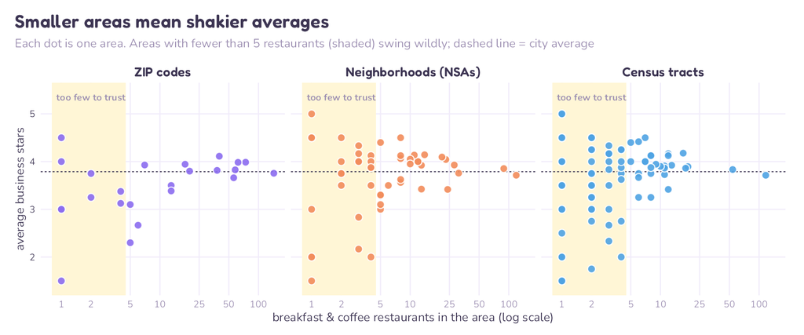

The smaller the areas, the fewer restaurants each one holds, and the more one restaurant can swing the average. Three out of four census tracts have fewer than 5 breakfast spots.

**The choice: ZIP codes**

enough restaurants per area · easy to understand · every restaurant matched

- **Enough restaurants to compare.** ZIP codes pool enough restaurants for the averages to mean something.
- **Easy to understand.** Anyone knows a ZIP code. Few people know their census tract number.
- **Nothing left out.** Every restaurant was matched to a ZIP code, including the 11 just outside the city.

**What ZIP codes hide.** ZIP codes are postal areas, not neighbourhoods. 70130 alone covers the Warehouse District and part of the French Quarter, so a great café and a tourist trap share one average. The 9 ZIP codes with fewer than 5 breakfast spots are mapped but not ranked.

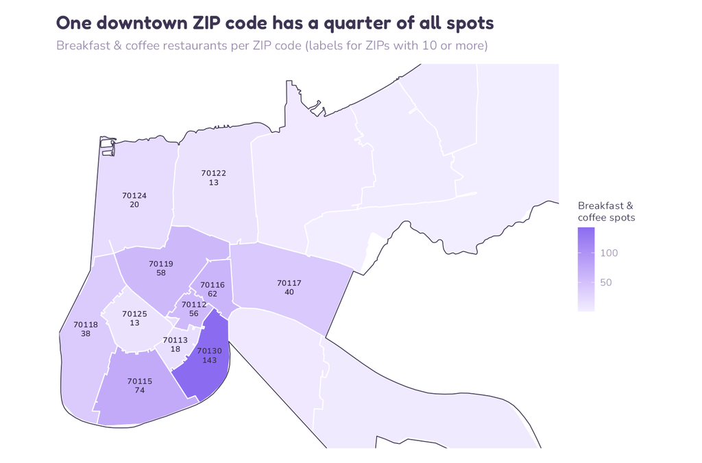

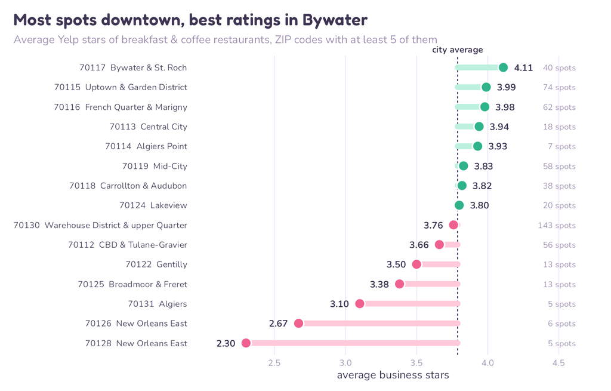

**Show the code: R/neighborhoods.R**

```r
# =============================================================================
# R/neighborhoods.R
# Step 6 (third system): Neighborhood Statistical Areas (NSAs), the City of
# New Orleans' own planning neighbourhoods. Also rebuilds the geographic
# comparison table with all three systems.
#
# Run from the project root, after R/analysis.R and R/boundaries.R:
#   Rscript R/neighborhoods.R
# =============================================================================

suppressPackageStartupMessages({
  library(dplyr)
  library(sf)
})
sf_use_s2(FALSE)

selected_restaurants <- readRDS("data/new_orleans/selected_restaurants.rds")
restaurant_points <- selected_restaurants |>
  filter(!is.na(longitude), !is.na(latitude)) |>
  st_as_sf(coords = c("longitude", "latitude"), crs = 4326, remove = FALSE)

nsa  <- st_read("data/boundaries/nsa_new_orleans.geojson", quiet = TRUE)
zcta <- st_read("data/boundaries/zcta_new_orleans.geojson", quiet = TRUE)

# Assign every restaurant to a ZIP code and a neighbourhood
restaurant_areas <- restaurant_points |>
  st_join(zcta, join = st_within, left = TRUE) |>
  rename(zip = area_id) |>
  st_join(nsa, join = st_within, left = TRUE) |>
  st_drop_geometry() |>
  select(business_id, zip, neighborhood)
saveRDS(restaurant_areas, "data/new_orleans/restaurant_areas.rds")

nsa_summary <- restaurant_points |>
  st_drop_geometry() |>
  left_join(restaurant_areas, by = "business_id") |>
  group_by(area_id = neighborhood) |>
  summarise(
    number_of_restaurants  = n(),
    average_business_stars = mean(stars, na.rm = TRUE),
    .groups = "drop"
  ) |>
  arrange(desc(number_of_restaurants))
saveRDS(nsa_summary, "data/new_orleans/nsa_summary.rds")

# ---- Comparison table with all three systems --------------------------------

summarise_system <- function(summary, label) {
  matched <- summary |> filter(!is.na(area_id))
  tibble(
    geographic_system     = label,
    number_of_areas       = nrow(matched),
    restaurants_assigned  = sum(matched$number_of_restaurants),
    unmatched_restaurants = sum(summary$number_of_restaurants[is.na(summary$area_id)]),
    smallest_area_count   = min(matched$number_of_restaurants),
    largest_area_count    = max(matched$number_of_restaurants)
  )
}

geographic_comparison <- bind_rows(
  summarise_system(readRDS("data/new_orleans/zcta_summary.rds"),  "ZIP/ZCTA"),
  summarise_system(readRDS("data/new_orleans/tract_summary.rds"), "Census tract"),
  summarise_system(nsa_summary, "Neighborhood Statistical Area")
)
print(as.data.frame(geographic_comparison))
print(head(as.data.frame(nsa_summary), 12))
write.csv(geographic_comparison, "data/new_orleans/geographic_comparison.csv", row.names = FALSE)
message("Saved restaurant_areas.rds, nsa_summary.rds, geographic_comparison.csv")
```

**Show the code: R/compare_systems.R**

```r
# =============================================================================
# R/compare_systems.R
# Step 6 (continued): compare ZIP/ZCTA, census tracts and Neighborhood
# Statistical Areas on area size and average business rating, using the
# summaries saved by R/analysis.R and R/neighborhoods.R.
# Also draws the headline chart for the README.
#
# Run from the project root, after R/neighborhoods.R:
#   Rscript R/compare_systems.R
# =============================================================================

suppressPackageStartupMessages({
  library(dplyr)
  library(ggplot2)
})
source("R/theme.R")

min_restaurants <- 5   # areas below this are mapped but not ranked

selected_restaurants <- readRDS("data/new_orleans/selected_restaurants.rds")
city_average <- mean(selected_restaurants$stars, na.rm = TRUE)

zcta_summary  <- readRDS("data/new_orleans/zcta_summary.rds")  |> mutate(system = "ZIP codes")
tract_summary <- readRDS("data/new_orleans/tract_summary.rds") |> mutate(system = "Census tracts")
nsa_summary   <- readRDS("data/new_orleans/nsa_summary.rds")   |> mutate(system = "Neighborhoods (NSAs)")

system_levels <- c("ZIP codes", "Neighborhoods (NSAs)", "Census tracts")
areas <- bind_rows(zcta_summary, tract_summary, nsa_summary) |>
  filter(!is.na(area_id)) |>
  mutate(system = factor(system, levels = system_levels))

# ---- Table: area size and rating by geographic system -----------------------

system_ratings <- areas |>
  group_by(system) |>
  summarise(
    number_of_areas              = n(),
    median_restaurants_per_area  = median(number_of_restaurants),
    areas_under_5                = sum(number_of_restaurants < min_restaurants),
    pct_areas_under_5            = round(100 * mean(number_of_restaurants < min_restaurants)),
    restaurants_in_areas_under_5 = sum(number_of_restaurants[number_of_restaurants < min_restaurants]),
    lowest_area_avg_stars        = round(min(average_business_stars[number_of_restaurants >= min_restaurants]), 2),
    highest_area_avg_stars       = round(max(average_business_stars[number_of_restaurants >= min_restaurants]), 2),
    .groups = "drop"
  )
print(as.data.frame(system_ratings))
write.csv(system_ratings, "data/new_orleans/system_ratings_comparison.csv", row.names = FALSE)

# ---- ZIP-level table (areas with enough restaurants to compare) -------------

# Main neighborhoods in each ZIP code, for readable labels
zip_neighborhoods <- c(
  "70112" = "CBD & Tulane-Gravier",      "70113" = "Central City",
  "70114" = "Algiers Point",             "70115" = "Uptown & Garden District",
  "70116" = "French Quarter & Marigny",  "70117" = "Bywater & St. Roch",
  "70118" = "Carrollton & Audubon",      "70119" = "Mid-City",
  "70122" = "Gentilly",                  "70124" = "Lakeview",
  "70125" = "Broadmoor & Freret",        "70126" = "New Orleans East",
  "70128" = "New Orleans East",          "70130" = "Warehouse District & upper Quarter",
  "70131" = "Algiers"
)

zcta_table <- zcta_summary |>
  filter(number_of_restaurants >= min_restaurants) |>
  transmute(zip = area_id,
            neighborhoods = unname(zip_neighborhoods[area_id]),
            restaurants = number_of_restaurants,
            average_business_stars = round(average_business_stars, 2)) |>
  arrange(desc(restaurants))
write.csv(zcta_table, "data/new_orleans/zcta_ratings.csv", row.names = FALSE)

# ---- Headline chart: average stars by ZIP vs. the city average --------------

hero <- zcta_table |>
  mutate(
    label    = paste0(zip, "  ", neighborhoods),
    label    = reorder(label, average_business_stars),
    better   = average_business_stars >= city_average,
    deep     = ifelse(better, theme_cols$above[["deep"]], theme_cols$below[["deep"]]),
    pastel   = ifelse(better, theme_cols$above[["fill"]], theme_cols$below[["fill"]]),
    value    = sprintf("%.2f", average_business_stars),
    count    = paste0(restaurants, " spots")
  )

p_hero <- ggplot(hero, aes(y = label)) +
  geom_vline(xintercept = city_average, linetype = "22", color = theme_cols$ink, linewidth = 0.6) +
  annotate("text", x = city_average, y = Inf, vjust = -0.5, label = "city average",
           family = plot_family, fontface = "bold", color = theme_cols$ink, size = 3.8, hjust = 0.5) +
  geom_segment(aes(x = city_average, xend = average_business_stars, yend = label, color = pastel),
               linewidth = 3.2, lineend = "round") +
  geom_point(aes(x = average_business_stars, fill = deep), shape = 21, color = "white",
             size = 5, stroke = 1.2) +
  geom_text(aes(x = average_business_stars, label = value,
                hjust = ifelse(better, -0.55, 1.55)),
            family = plot_family, fontface = "bold", color = theme_cols$ink, size = 3.9) +
  geom_text(aes(x = 4.62, label = count), family = plot_family, color = theme_cols$muted,
            size = 3.5, hjust = 1) +
  scale_color_identity() +
  scale_fill_identity() +
  scale_x_continuous(limits = c(2.05, 4.62), breaks = seq(2.5, 4.5, 0.5)) +
  coord_cartesian(clip = "off") +
  labs(
    title = "Most spots downtown, best ratings in Bywater",
    subtitle = "Average Yelp stars of breakfast & coffee restaurants, ZIP codes with at least 5 of them",
    x = "average business stars", y = NULL
  ) +
  theme_pastel() +
  theme(panel.grid.major.y = element_blank())

save_plot(p_hero, "figures/zip_ratings_chart.png", width = 10, height = 6.4)

# ---- Comparison plot: restaurants per area vs. average rating ---------------

system_colors <- c("ZIP codes" = theme_cols$zcta[["deep"]], "Census tracts" = theme_cols$tract[["deep"]],
                   "Neighborhoods (NSAs)" = theme_cols$nsa[["deep"]])

p_compare <- ggplot(areas, aes(number_of_restaurants, average_business_stars)) +
  annotate("rect", xmin = 0.8, xmax = min_restaurants - 0.5, ymin = -Inf, ymax = Inf,
           fill = theme_cols$band) +
  annotate("text", x = 2, y = 5.35, label = "too few to trust", family = plot_family,
           fontface = "bold", color = theme_cols$muted, size = 3.6) +
  geom_hline(yintercept = city_average, linetype = "22", color = theme_cols$ink, linewidth = 0.5) +
  geom_point(aes(fill = system), shape = 21, color = "white", size = 3.4, stroke = 0.8, alpha = 0.9,
             show.legend = FALSE) +
  scale_fill_manual(values = system_colors) +
  scale_x_log10(breaks = c(1, 2, 5, 10, 25, 50, 100)) +
  scale_y_continuous(limits = c(1.4, 5.45), breaks = 1:5) +
  facet_wrap(~ system) +
  labs(
    title = "Smaller areas mean shakier averages",
    subtitle = paste0("Each dot is one area. Areas with fewer than ", min_restaurants,
                      " restaurants (shaded) swing wildly; dashed line = city average"),
    x = "breakfast & coffee restaurants in the area (log scale)",
    y = "average business stars"
  ) +
  theme_pastel()

save_plot(p_compare, "figures/geographic_system_comparison.png", width = 12, height = 5)

message("Saved figures/zip_ratings_chart.png, figures/geographic_system_comparison.png, ",
        "data/new_orleans/system_ratings_comparison.csv, zcta_ratings.csv")
```

## 6 Adjusting for reviewer habits

Some reviewers give almost every restaurant five stars; others rarely do. A 4-star review means more from a tough reviewer than from an easy one.

For each reviewer, work out their **usual rating**. Then score every review as *stars given minus that reviewer’s usual*. A reviewer who usually gives 3 stars and gives a place 4 adds **+1**. A reviewer who usually gives 5 and gives 4 adds **−1**. A restaurant’s adjusted score is the average of these.

**Who counts as an active reviewer?** A usual rating only means something if the reviewer has rated enough places. Reviewers with at least **5 breakfast & coffee reviews** were kept:

| Minimum reviews | Reviewers kept | Share of reviewers | Reviews kept | Share of reviews | Restaurants ranked |
| --- | --- | --- | --- | --- | --- |
| 3 | 11,531 | 11.8% | 57,617 | 36.1% | 448 |
| **5** | **3,416** | **3.5%** | **30,918** | **19.4%** | **394** |
| 10 | 784 | 0.8% | 14,919 | 9.4% | 325 |

Only 3.5% of reviewers qualify, but they wrote almost a fifth of all reviews. A higher threshold gives each reviewer a better baseline, but leaves fewer restaurants to rank.

**Mean or median?** The **mean** was used as each reviewer’s usual rating. Ratings are whole stars, so with a median baseline **49%** of reviews get an adjusted score of exactly 0, throwing away most of the information. With the mean, only 5% do. The typical active reviewer averages 4.0 stars, but the range is wide: 2.9 at the 5th percentile, 4.8 at the 95th.

[figure not shown]

Ranks before and after adjustment are strongly related (rank correlation **0.83**), but a few restaurants move hundreds of places:

| Restaurant | ZIP | Stars (all reviewers) | Stars (active reviewers) | Rank before | Rank after |
| --- | --- | --- | --- | --- | --- |
| First Cup Cafe | 70125 | 3.44 | 4.47 | 331st | **12th** |
| Chris’ Cakes and Donuts | 70128 | 3.00 | 3.82 | 374th | 142nd |
| Rare Form | 70116 | 3.85 | 4.27 | 251st | 29th |
| Le Citron Bistro | 70130 | 3.81 | 4.10 | 260th | 38th |
| The Flying Pig Cafe | 70115 | 4.13 | 3.30 | 161st | **365th** |
| Louise | 70117 | 4.21 | 3.83 | 125th | 320th |
| Wakin’ Bakin’ | 70115 | 4.23 | 3.79 | 121st | 307th |
| Streetcar Cafe | 70130 | 4.39 | 4.19 | 74th | 259th |

The moves have two causes. **Reviewer behaviour:** First Cup Cafe’s active reviewers rate it a full star higher than casual reviewers do. **Small samples:** most of these restaurants have only 10 to 25 active-reviewer reviews, so a few reviews move them a long way.

**Show the code: R/reviewers.R**

```r
# =============================================================================
# R/reviewers.R
# Step 7: ratings from all reviewers vs. reviewer-adjusted scores
#
# Run from the project root, after R/clean.R:
#   Rscript R/reviewers.R
#
# Idea: some reviewers give almost everything 5 stars, others rarely do.
# For each reviewer we compute their usual (baseline) rating across the
# breakfast & coffee restaurants they reviewed, and subtract it from each of
# their ratings. A normalized score of +0.6 means "this reviewer rated this
# place 0.6 stars above what they usually give". It is NOT a new Yelp rating.
# =============================================================================

suppressPackageStartupMessages({
  library(dplyr)
  library(tidyr)
  library(lubridate)
  library(ggplot2)
  library(ggrepel)
})
source("R/theme.R")

min_reviewer_reviews   <- 5    # a reviewer needs this many reviews to get a baseline
min_eligible_reviews   <- 10   # a restaurant needs this many eligible reviews to be ranked
thresholds_to_test     <- c(3, 5, 10)

selected_restaurants <- readRDS("data/new_orleans/selected_restaurants.rds")
category_reviews <- readRDS("data/new_orleans/selected_reviews.rds") |>
  mutate(review_date = ymd_hms(date), review_year = year(review_date))

# ---- All reviewers -----------------------------------------------------------

all_reviewer_summary <- category_reviews |>
  group_by(business_id) |>
  summarise(
    number_of_reviews_all_reviewers = n(),
    average_stars_all_reviewers     = mean(stars, na.rm = TRUE),
    median_stars_all_reviewers      = median(stars, na.rm = TRUE),
    .groups = "drop"
  )

# ---- Reviewer activity and baselines -------------------------------------------

reviewer_baselines <- category_reviews |>
  group_by(user_id) |>
  summarise(
    reviewer_mean         = mean(stars, na.rm = TRUE),
    reviewer_median       = median(stars, na.rm = TRUE),
    reviewer_review_count = n(),
    .groups = "drop"
  )

category_reviews_adjusted <- category_reviews |>
  left_join(reviewer_baselines, by = "user_id") |>
  mutate(
    normalized_mean_score   = stars - reviewer_mean,
    normalized_median_score = stars - reviewer_median
  )

# How many reviewers and reviews survive each activity threshold?
threshold_table <- tibble(min_reviews = thresholds_to_test) |>
  rowwise() |>
  mutate(
    reviewers_kept     = sum(reviewer_baselines$reviewer_review_count >= min_reviews),
    pct_of_reviewers   = round(100 * reviewers_kept / nrow(reviewer_baselines), 1),
    reviews_kept       = sum(category_reviews_adjusted$reviewer_review_count >= min_reviews),
    pct_of_reviews     = round(100 * reviews_kept / nrow(category_reviews_adjusted), 1),
    restaurants_ranked = category_reviews_adjusted |>
      filter(reviewer_review_count >= min_reviews) |>
      count(business_id) |>
      filter(n >= min_eligible_reviews) |>
      nrow()
  ) |>
  ungroup()

# Why the mean baseline: with whole-star ratings, the median baseline gives a
# normalized score of exactly 0 for a large share of reviews.
eligible_adjusted_reviews <- category_reviews_adjusted |>
  filter(reviewer_review_count >= min_reviewer_reviews)

baseline_check <- tibble(
  share_zero_with_median_baseline = round(mean(eligible_adjusted_reviews$normalized_median_score == 0), 3),
  share_zero_with_mean_baseline   = round(mean(abs(eligible_adjusted_reviews$normalized_mean_score) < 1e-9), 3),
  typical_reviewer_mean           = round(median(reviewer_baselines$reviewer_mean[reviewer_baselines$reviewer_review_count >= min_reviewer_reviews]), 2),
  reviewer_mean_5th_percentile    = round(quantile(reviewer_baselines$reviewer_mean[reviewer_baselines$reviewer_review_count >= min_reviewer_reviews], 0.05), 2),
  reviewer_mean_95th_percentile   = round(quantile(reviewer_baselines$reviewer_mean[reviewer_baselines$reviewer_review_count >= min_reviewer_reviews], 0.95), 2)
)

# ---- Restaurant-level comparison ---------------------------------------------

adjusted_summary <- eligible_adjusted_reviews |>
  group_by(business_id) |>
  summarise(
    number_of_reviews_eligible_reviewers = n(),
    average_stars_eligible_reviewers     = mean(stars, na.rm = TRUE),
    average_normalized_score             = mean(normalized_mean_score, na.rm = TRUE),
    median_normalized_score              = median(normalized_mean_score, na.rm = TRUE),
    average_normalized_median_score      = mean(normalized_median_score, na.rm = TRUE),
    .groups = "drop"
  )

restaurant_summary <- selected_restaurants |>
  select(business_id, business_name, address, postal_code, latitude, longitude,
         yelp_stars = stars, categories) |>
  left_join(all_reviewer_summary, by = "business_id") |>
  left_join(adjusted_summary, by = "business_id") |>
  arrange(desc(average_normalized_score))

ranked <- restaurant_summary |>
  filter(number_of_reviews_eligible_reviewers >= min_eligible_reviews) |>
  mutate(
    rank_all_reviewers = min_rank(desc(average_stars_all_reviewers)),
    rank_adjusted      = min_rank(desc(average_normalized_score)),
    rank_change        = rank_all_reviewers - rank_adjusted   # positive = moves up
  )

# ---- Top 10 ------------------------------------------------------------------

top10 <- ranked |>
  arrange(desc(average_normalized_score)) |>
  slice_head(n = 10) |>
  mutate(top_rank = row_number())

# Robustness: does the top 10 change with other choices?
top10_with <- function(min_rev, min_elig, score = "average_normalized_score") {
  category_reviews_adjusted |>
    filter(reviewer_review_count >= min_rev) |>
    group_by(business_id) |>
    summarise(n = n(),
              average_normalized_score = mean(normalized_mean_score),
              average_normalized_median_score = mean(normalized_median_score),
              .groups = "drop") |>
    filter(n >= min_elig) |>
    arrange(desc(.data[[score]])) |>
    slice_head(n = 10) |>
    pull(business_id)
}
robustness <- tibble(
  version = c("Reviewers with 3+ reviews", "Reviewers with 10+ reviews",
              "Restaurants need 20+ eligible reviews", "Median baseline instead of mean",
              "Plain average stars (all reviewers)"),
  ids = list(top10_with(3, min_eligible_reviews), top10_with(10, min_eligible_reviews),
             top10_with(min_reviewer_reviews, 20),
             top10_with(min_reviewer_reviews, min_eligible_reviews, "average_normalized_median_score"),
             ranked |> arrange(desc(average_stars_all_reviewers)) |> slice_head(n = 10) |> pull(business_id))
) |>
  mutate(top10_restaurants_kept = sapply(ids, function(x) sum(x %in% top10$business_id))) |>
  select(-ids)

# Biggest movers among ranked restaurants
movers <- bind_rows(
  ranked |> arrange(desc(rank_change)) |> slice_head(n = 5) |> mutate(direction = "up"),
  ranked |> arrange(rank_change) |> slice_head(n = 5) |> mutate(direction = "down")
) |>
  select(direction, business_name, postal_code, number_of_reviews_all_reviewers,
         average_stars_all_reviewers, number_of_reviews_eligible_reviewers,
         average_stars_eligible_reviewers, average_normalized_score,
         rank_all_reviewers, rank_adjusted, rank_change)

# ---- Save --------------------------------------------------------------------

saveRDS(restaurant_summary, "data/new_orleans/restaurant_summary.rds")
write.csv(threshold_table, "data/new_orleans/reviewer_thresholds.csv", row.names = FALSE)
write.csv(baseline_check, "data/new_orleans/baseline_check.csv", row.names = FALSE)
write.csv(robustness, "data/new_orleans/top10_robustness.csv", row.names = FALSE)
write.csv(movers |> mutate(across(where(is.double), ~ round(.x, 2))),
          "data/new_orleans/rank_movers.csv", row.names = FALSE)
write.csv(top10 |>
            transmute(top_rank, business_name, address, postal_code,
                      reviews_all = number_of_reviews_all_reviewers,
                      avg_stars_all = round(average_stars_all_reviewers, 2),
                      reviews_eligible = number_of_reviews_eligible_reviewers,
                      avg_stars_eligible = round(average_stars_eligible_reviewers, 2),
                      avg_normalized_score = round(average_normalized_score, 2),
                      rank_all_reviewers),
          "data/new_orleans/top10_restaurants.csv", row.names = FALSE)
saveRDS(top10, "data/new_orleans/top10.rds")
saveRDS(ranked, "data/new_orleans/ranked_restaurants.rds")

print(threshold_table); print(baseline_check); print(robustness)
print(as.data.frame(movers |> mutate(across(where(is.double), ~ round(.x, 2)))))
print(as.data.frame(top10 |> select(top_rank, business_name, postal_code,
                                    number_of_reviews_all_reviewers, average_stars_all_reviewers,
                                    number_of_reviews_eligible_reviewers, average_normalized_score,
                                    rank_all_reviewers)))

# ---- Plot: raw vs. adjusted --------------------------------------------------

mover_names <- c(movers$business_name[movers$direction == "up"][1:2],
                 movers$business_name[movers$direction == "down"][1:2])
plot_data <- ranked |>
  mutate(group = case_when(
    business_id %in% top10$business_id ~ "top10",
    business_name %in% mover_names     ~ "mover",
    TRUE                               ~ "other"
  ))
top_labels   <- plot_data |> filter(group == "top10") |>
  left_join(top10 |> select(business_id, top_rank), by = "business_id")
mover_labels <- plot_data |> filter(group == "mover")

p_adjusted <- ggplot(plot_data, aes(average_stars_all_reviewers, average_normalized_score)) +
  geom_hline(yintercept = 0, linetype = "22", color = theme_cols$ink, linewidth = 0.5) +
  geom_point(data = filter(plot_data, group == "other"), shape = 21, size = 2.6,
             fill = theme_cols$tract[["fill"]], color = "white", stroke = 0.4) +
  geom_point(data = mover_labels, shape = 21, size = 3.6,
             fill = theme_cols$below[["deep"]], color = "white", stroke = 0.8) +
  geom_point(data = top_labels, shape = 21, size = 4.2,
             fill = theme_cols$zcta[["deep"]], color = "white", stroke = 0.8) +
  geom_text_repel(data = top_labels, aes(label = top_rank), family = plot_family,
                  fontface = "bold", color = theme_cols$ink, size = 3.4,
                  min.segment.length = 0.2, segment.color = theme_cols$muted,
                  box.padding = 0.25, point.padding = 0.15, max.overlaps = Inf, seed = 167) +
  geom_label_repel(data = mover_labels,
                   aes(label = paste0(business_name, "\n", rank_all_reviewers, "th \u2192 ", rank_adjusted, "th")),
                   family = plot_family, color = theme_cols$ink, size = 3.2, label.size = 0,
                   fill = alpha("white", 0.85), lineheight = 0.95, min.segment.length = 0,
                   segment.color = theme_cols$muted, box.padding = 0.6, nudge_y = 0.25, seed = 167) +
  annotate("text", x = 1.15, y = 0.85, hjust = 0, label = "rated higher than\nreviewers usually rate",
           family = plot_family, color = theme_cols$muted, size = 3.4, lineheight = 0.9) +
  annotate("text", x = 1.15, y = -1.5, hjust = 0, label = "rated lower than\nreviewers usually rate",
           family = plot_family, color = theme_cols$muted, size = 3.4, lineheight = 0.9) +
  scale_x_continuous(limits = c(1.1, 5), breaks = 1:5) +
  labs(
    title = "Adjusting for reviewer habits mostly agrees with Yelp",
    subtitle = paste0(nrow(ranked), " restaurants with ", min_eligible_reviews,
                      "+ reviews from active reviewers. Orange = top 10, pink = biggest rank changes"),
    x = "average stars from all reviewers",
    y = "average normalized score"
  ) +
  theme_pastel()

save_plot(p_adjusted, "figures/raw_vs_adjusted.png", width = 10, height = 6.6)
message("Saved Step 7 tables in data/new_orleans/ and figures/raw_vs_adjusted.png")
```

## 7 The answer

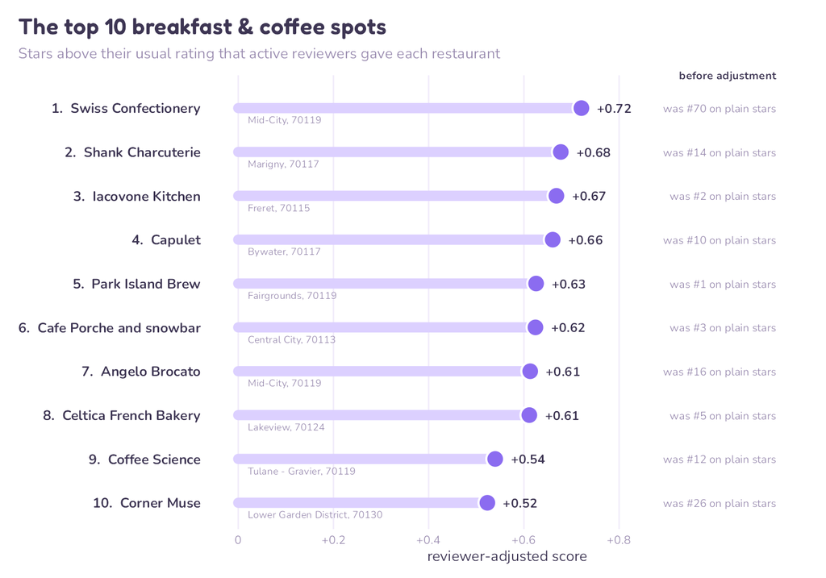

| Rank | Restaurant | Neighbourhood (ZIP) | Yelp reviews | Average stars | Adjusted score | Rank on plain stars |
| --- | --- | --- | --- | --- | --- | --- |
| 1 | Swiss Confectionery | Mid-City (70119) | 55 | 4.42 | +0.72 | 70th |
| 2 | Shank Charcuterie | Marigny (70117) | 44 | 4.68 | +0.68 | 14th |
| 3 | Iacovone Kitchen | Freret (70115) | 40 | 4.85 | +0.67 | 2nd |
| 4 | Capulet | Bywater (70117) | 50 | 4.72 | +0.66 | 10th |
| 5 | Park Island Brew | Fairgrounds (70119) | 48 | 4.85 | +0.63 | 1st |
| 6 | Cafe Porche and snowbar | Central City (70113) | 176 | 4.83 | +0.62 | 3rd |
| 7 | Angelo Brocato | Mid-City (70119) | 650 | 4.67 | +0.61 | 16th |
| 8 | Celtica French Bakery | Lakeview (70124) | 30 | 4.77 | +0.61 | 5th |
| 9 | Coffee Science | Tulane-Gravier (70119) | 93 | 4.70 | +0.54 | 12th |
| 10 | Corner Muse | Lower Garden District (70130) | 55 | 4.60 | +0.52 | 26th |

**Which area is best?** ZIP codes with at least 10 ranked restaurants:

| ZIP | Main neighbourhoods | Ranked | Above reviewers’ usual | In top 10 | In top 50 | Average adjusted score |
| --- | --- | --- | --- | --- | --- | --- |
| 70117 | Bywater & St. Roch | 30 | **60%** | 2 | 8 | **+0.11** |
| 70113 | Central City | 10 | 70% | 1 | 2 | +0.03 |
| 70119 | Mid-City | 43 | 53% | **4** | 8 | −0.01 |
| 70115 | Uptown & Garden District | 62 | 53% | 1 | 7 | −0.02 |
| 70116 | French Quarter & Marigny | 39 | 54% | 0 | 4 | −0.06 |
| 70124 | Lakeview | 17 | 41% | 1 | 1 | −0.10 |
| 70130 | Warehouse District & upper French Quarter | 98 | 44% | 1 | **9** | −0.12 |
| 70112 | CBD & Tulane-Gravier | 33 | 42% | 0 | 2 | −0.13 |
| 70118 | Carrollton & Audubon | 31 | 45% | 0 | 4 | −0.14 |

**Best area: Bywater & St. Roch (70117)**

highest Yelp stars of any ZIP code with 5+ spots (4.11) · top adjusted score (+0.11) · 60% of its restaurants beat their reviewers’ usual

- **Mid-City (70119)** is where the top picks are: 4 of the top 10.
- **Downtown (70130)** has the most choice (143 spots, a quarter of the total) and 9 of the top 50, but its restaurants score *below* their reviewers’ usual on average.
- 70113 has the highest share above usual, but only 10 ranked restaurants, so 70117 is the better-supported answer.

**Show the code: R/maps.R**

```r
# =============================================================================
# R/maps.R
# All maps in the README, plus the ZIP-level reviewer-adjusted summary.
#
#   figures/new_orleans_boundary_map.png   Step 5: restaurants inside the city
#   figures/zcta_restaurant_count_map.png  Step 6: restaurants per ZIP code
#   figures/top10_map.png                  Final answer: top 10 + ZIP scores
#
# Run from the project root, after R/boundaries.R, R/neighborhoods.R and
# R/reviewers.R:
#   Rscript R/maps.R
# =============================================================================

suppressPackageStartupMessages({
  library(dplyr)
  library(sf)
  library(ggplot2)
  library(ggrepel)
})
source("R/theme.R")
sf_use_s2(FALSE)

min_ranked_per_zip <- 10   # ZIPs need this many ranked restaurants to get a score

zcta <- st_read("data/boundaries/zcta_new_orleans.geojson", quiet = TRUE)
nsa  <- st_read("data/boundaries/nsa_new_orleans.geojson", quiet = TRUE)
city <- st_union(nsa) |> st_sf()             # NSAs tile the whole city

selected_restaurants <- readRDS("data/new_orleans/selected_restaurants.rds")
restaurant_areas     <- readRDS("data/new_orleans/restaurant_areas.rds")
ranked               <- readRDS("data/new_orleans/ranked_restaurants.rds") |>
  left_join(restaurant_areas, by = "business_id")
top10                <- readRDS("data/new_orleans/top10.rds") |>
  left_join(restaurant_areas, by = "business_id")

points <- selected_restaurants |>
  st_as_sf(coords = c("longitude", "latitude"), crs = 4326, remove = FALSE)
points_in_city <- points[lengths(st_within(points, city)) > 0, ]

zcta_city <- st_intersection(zcta, city)     # ZIP shapes clipped to the city
zip_centers <- st_point_on_surface(zcta_city)

map_theme <- theme_pastel() +
  theme(axis.text = element_blank(), axis.text.x = element_blank(), axis.text.y = element_blank(),
        axis.title = element_blank(),
        panel.grid.major = element_blank(), legend.position = "right",
        legend.title = element_text(color = theme_cols$ink, size = 11),
        legend.text = element_text(color = theme_cols$muted))

# ---- ZIP-level reviewer-adjusted summary -------------------------------------

zip_adjusted <- ranked |>
  group_by(zip) |>
  summarise(
    ranked_restaurants       = n(),
    pct_above_usual          = round(100 * mean(average_normalized_score > 0)),
    in_top_10                = sum(business_id %in% top10$business_id),
    in_top_50                = sum(rank_adjusted <= 50),
    average_stars_all        = mean(average_stars_all_reviewers),
    average_normalized_score = mean(average_normalized_score),
    .groups = "drop"
  ) |>
  arrange(desc(average_normalized_score))
write.csv(zip_adjusted |> mutate(across(c(average_stars_all, average_normalized_score), ~ round(.x, 2))),
          "data/new_orleans/zip_adjusted_scores.csv", row.names = FALSE)
print(as.data.frame(zip_adjusted))

# ---- Map 1: restaurants inside the city boundary (Step 5) --------------------

p_boundary <- ggplot() +
  geom_sf(data = city, fill = "#FDFBFF", color = theme_cols$ink, linewidth = 0.4) +
  geom_sf(data = points_in_city |> arrange(stars), aes(fill = stars),
          shape = 21, color = "white", stroke = 0.3, size = 2.4) +
  scale_fill_gradient(low = "#FFC9DA", high = "#7B4FE0", limits = c(1, 5),
                      name = "Yelp stars") +
  coord_sf(xlim = c(-90.14, -89.90), ylim = c(29.90, 30.06), expand = FALSE) +
  labs(title = "Breakfast & coffee spots cluster along the river",
       subtitle = paste0(nrow(points_in_city), " restaurants inside the official city boundary, ",
                         "coloured by Yelp stars")) +
  map_theme

save_plot(p_boundary, "figures/new_orleans_boundary_map.png", width = 10, height = 6.6)

# ---- Map 2: restaurants per ZIP code (Step 6) --------------------------------

zip_counts <- readRDS("data/new_orleans/zcta_summary.rds")
zcta_count_map <- zcta_city |> left_join(zip_counts, by = "area_id")
count_labels <- zip_centers |>
  left_join(zip_counts, by = "area_id") |>
  filter(number_of_restaurants >= 10)

p_zcta <- ggplot() +
  geom_sf(data = zcta_count_map, aes(fill = number_of_restaurants), color = "white", linewidth = 0.5) +
  geom_sf(data = city, fill = NA, color = theme_cols$ink, linewidth = 0.4) +
  geom_sf_text(data = count_labels, aes(label = paste0(area_id, "\n", number_of_restaurants)),
               family = plot_family, size = 3, color = theme_cols$ink, lineheight = 0.9,
               fontface = "bold") +
  scale_fill_gradient(low = "#F3EEFF", high = "#8B6CF0", na.value = "#F6F4FA",
                      name = "Breakfast &\ncoffee spots") +
  coord_sf(xlim = c(-90.14, -89.90), ylim = c(29.90, 30.06), expand = FALSE) +
  labs(title = "One downtown ZIP code has a quarter of all spots",
       subtitle = "Breakfast & coffee restaurants per ZIP code (labels for ZIPs with 10 or more)") +
  map_theme

save_plot(p_zcta, "figures/zcta_restaurant_count_map.png", width = 10, height = 6.6)

# ---- Map 3: the answer - top 10 and ZIP-level adjusted scores ----------------

zip_score_map <- zcta_city |>
  left_join(zip_adjusted, by = c("area_id" = "zip")) |>
  mutate(score = ifelse(ranked_restaurants >= min_ranked_per_zip, average_normalized_score, NA))

score_labels <- zip_centers |>
  left_join(zip_adjusted, by = c("area_id" = "zip")) |>
  filter(ranked_restaurants >= min_ranked_per_zip)

top10_points <- top10 |>
  st_as_sf(coords = c("longitude", "latitude"), crs = 4326, remove = FALSE)

view <- list(x = c(-90.135, -90.02), y = c(29.915, 30.03))

p_top10 <- ggplot() +
  geom_sf(data = zip_score_map, aes(fill = score), color = "white", linewidth = 0.6) +
  geom_sf(data = city, fill = NA, color = theme_cols$ink, linewidth = 0.4) +
  geom_sf(data = points_in_city, shape = 16, size = 0.9, color = alpha(theme_cols$ink, 0.25)) +
  geom_sf_text(data = score_labels, aes(label = area_id), family = plot_family,
               size = 3, color = alpha(theme_cols$ink, 0.55), fontface = "bold",
               nudge_y = -0.004) +
  geom_sf(data = top10_points, shape = 21, size = 6.5, fill = theme_cols$zcta[["deep"]],
          color = "white", stroke = 1.1) +
  geom_sf_text(data = top10_points, aes(label = top_rank), family = plot_family,
               size = 3.1, color = "white", fontface = "bold") +
  geom_label_repel(data = top10, aes(longitude, latitude, label = business_name),
                   family = plot_family, size = 3.2, color = theme_cols$ink,
                   fill = alpha("white", 0.9), label.size = 0, label.padding = 0.18,
                   box.padding = 0.7, point.padding = 0.6, min.segment.length = 0,
                   segment.color = theme_cols$muted, max.overlaps = Inf, seed = 10) +
  scale_fill_gradient2(low = theme_cols$below[["deep"]], mid = "#F6F3FB",
                       high = theme_cols$above[["deep"]], midpoint = 0,
                       limits = c(-0.25, 0.25), oob = scales::squish, na.value = "#FBFAFD",
                       name = "ZIP average\nnormalized score",
                       breaks = c(-0.2, 0, 0.2), labels = c("-0.2 (below usual)", "0", "+0.2 (above usual)")) +
  coord_sf(xlim = view$x, ylim = view$y, expand = FALSE) +
  labs(title = "The top 10 breakfast & coffee spots",
       subtitle = paste0("ZIP colour = average reviewer-adjusted score (ZIPs with ", min_ranked_per_zip,
                         "+ ranked restaurants). Grey dots = all other spots")) +
  map_theme

save_plot(p_top10, "figures/top10_map.png", width = 11, height = 8.4)
message("Saved figures/new_orleans_boundary_map.png, zcta_restaurant_count_map.png, top10_map.png")
```

**Show the code: R/charts.R**

```r
# =============================================================================
# R/charts.R
# Two summary charts for the report:
#   figures/category_chart.png   Step 3: where the selected categories sit
#   figures/top10_chart.png      The answer: top 10 by reviewer-adjusted score
#
# Run from the project root, after R/clean.R and R/reviewers.R:
#   Rscript R/charts.R
# =============================================================================

suppressPackageStartupMessages({
  library(dplyr)
  library(ggplot2)
})
source("R/theme.R")

selected_categories <- c("Breakfast & Brunch", "Coffee & Tea", "Cafes", "Bakeries")

# ---- Category chart ----------------------------------------------------------

category_counts <- read.csv("data/new_orleans/category_counts.csv")
top_categories <- category_counts |>
  filter(!category %in% c("Restaurants", "Food")) |>
  filter(rank(-n, ties.method = "first") <= 14 | category %in% selected_categories) |>
  mutate(selected = category %in% selected_categories,
         category = reorder(category, n))

p_categories <- ggplot(top_categories, aes(n, category)) +
  geom_col(aes(fill = selected), width = 0.62) +
  geom_text(aes(label = n, color = selected), hjust = -0.25, family = plot_family,
            fontface = "bold", size = 3.6) +
  scale_fill_manual(values = c(`TRUE` = theme_cols$zcta[["deep"]], `FALSE` = theme_cols$tract[["fill"]]),
                    guide = "none") +
  scale_color_manual(values = c(`TRUE` = theme_cols$ink, `FALSE` = theme_cols$muted), guide = "none") +
  scale_x_continuous(expand = expansion(mult = c(0, 0.1))) +
  labs(
    title = "Breakfast & coffee: four categories, one morning",
    subtitle = "Most common categories among 2,261 New Orleans restaurants, plus Bakeries. Orange = the four chosen",
    x = "restaurants", y = NULL
  ) +
  theme_pastel() +
  theme(panel.grid.major.y = element_blank(),
        axis.text.y = element_text(color = theme_cols$ink, size = 11.5))

save_plot(p_categories, "figures/category_chart.png", width = 10, height = 6.2)

# ---- Top 10 chart ------------------------------------------------------------

top10 <- readRDS("data/new_orleans/top10.rds") |>
  left_join(readRDS("data/new_orleans/restaurant_areas.rds"), by = "business_id") |>
  mutate(
    label = paste0(top_rank, ".  ", business_name),
    label = reorder(label, -top_rank),
    was   = paste0("was #", rank_all_reviewers, " on plain stars"),
    where = paste0(neighborhood, ", ", zip)
  )

p_top10 <- ggplot(top10, aes(y = label)) +
  geom_segment(aes(x = 0, xend = average_normalized_score, yend = label),
               color = theme_cols$zcta[["fill"]], linewidth = 4.2, lineend = "round") +
  geom_point(aes(x = average_normalized_score), shape = 21, size = 6.4,
             fill = theme_cols$zcta[["deep"]], color = "white", stroke = 1.3) +
  geom_text(aes(x = average_normalized_score, label = sprintf("+%.2f", average_normalized_score)),
            hjust = -0.45, family = plot_family, fontface = "bold", color = theme_cols$ink, size = 4) +
  geom_text(aes(x = 0.02, label = where), vjust = 2.15, hjust = 0, family = plot_family,
            color = theme_cols$muted, size = 3.1) +
  geom_text(aes(x = 1.13, label = was), hjust = 1, family = plot_family,
            color = theme_cols$muted, size = 3.4) +
  annotate("text", x = 1.13, y = 10.75, hjust = 1, label = "before adjustment",
           family = plot_family, fontface = "bold", color = theme_cols$ink, size = 3.5) +
  scale_x_continuous(limits = c(0, 1.13), breaks = seq(0, 0.8, 0.2),
                     labels = function(x) ifelse(x == 0, "0", sprintf("+%.1f", x))) +
  coord_cartesian(clip = "off") +
  labs(
    title = "The top 10 breakfast & coffee spots",
    subtitle = "Stars above their usual rating that active reviewers gave each restaurant",
    x = "reviewer-adjusted score", y = NULL
  ) +
  theme_pastel() +
  theme(panel.grid.major.y = element_blank(),
        axis.text.y = element_text(color = theme_cols$ink, size = 12, face = "bold",
                                   margin = margin(r = 6)))

save_plot(p_top10, "figures/top10_chart.png", width = 10, height = 7)
message("Saved figures/category_chart.png and figures/top10_chart.png")
```

## 8 How sure is the top 10?

Changing one choice at a time:

| Version | Restaurants still in the top 10 |
| --- | --- |
| Reviewers with 3+ reviews count as active | 6 of 10 |
| Reviewers with 10+ reviews count as active | 6 of 10 |
| Median baseline instead of mean | 8 of 10 |
| Restaurants need 20+ active-reviewer reviews | 3 of 10 |
| Plain Yelp average (no adjustment) | 5 of 10 |

The exact list is sensitive, mostly because many top restaurants are small, with 10 to 20 active-reviewer reviews. The **area** answer is steadier: in every adjusted version, Mid-City (70119) and Bywater & Marigny (70117) together hold at least half of the top 10.

**Is it luck?** The table above changes the *rules*. A second question is how much the list depends on *chance*: which active reviewers happened to visit each place. To test this, each ranked restaurant’s reviews were **bootstrapped**: resampled with replacement 2,000 times. Each time the scores were recalculated and all 394 restaurants re-ranked.

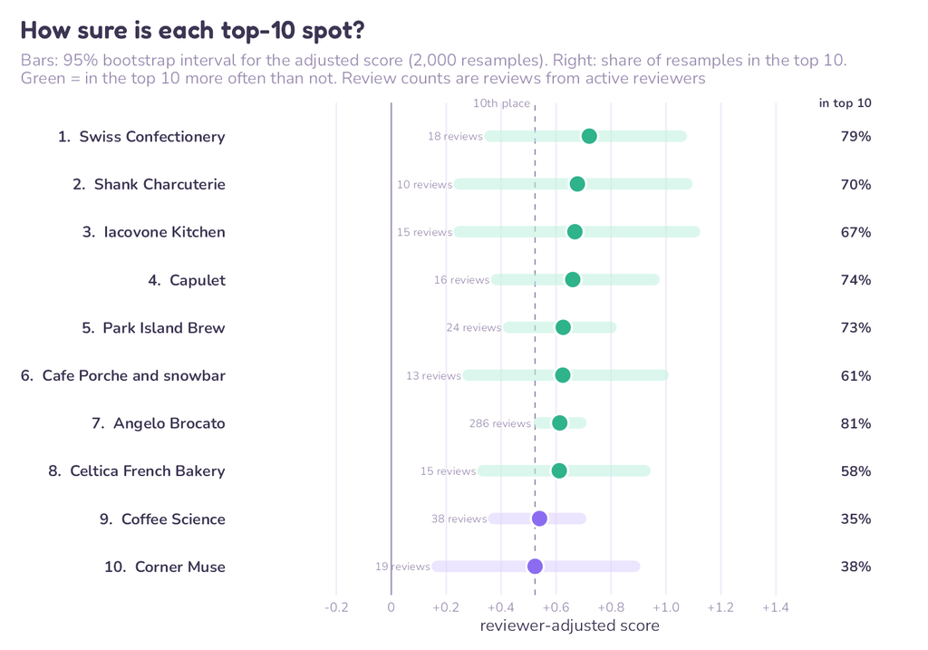

All ten intervals stay **above zero**, so every top-10 spot is rated above its reviewers’ usual even in unlucky resamples. **Angelo Brocato is the safest pick** (top 10 in 81% of resamples): 286 active-reviewer reviews pin its score down. Most of the others rest on 10 to 24 reviews, so their intervals are wide. Places **9 and 10** (Coffee Science and Corner Muse) make the top 10 in fewer than 40% of resamples. That is about as often as Pepperoni Ray’s Cafe (33%) and First Cup Cafe (25%) just outside it.

**Does the area answer survive?** Across the same 2,000 resamples:

| Check | Share of resamples |
| --- | --- |
| Mid-City (70119) has the most top-10 spots (ties included) | **86%** |
| Mid-City (70119) and Bywater & Marigny (70117) hold at least half of the top 10 | 69% |
| Bywater & Marigny (70117) has the most top-10 spots (ties included) | 33% |
| Downtown (70130) has the most top-10 spots (ties included) | 4% |

**Show the code: R/bootstrap.R**

```r
# =============================================================================
# R/bootstrap.R
# How sure is the top 10? Bootstrap confidence intervals and top-10 chances.
#
# Run from the project root, after R/clean.R (uses the same rules as
# R/reviewers.R):
#   Rscript R/bootstrap.R
#
# Idea: each restaurant's adjusted score is an average of only 10 to a few
# hundred reviews. If a different set of active reviewers had happened to
# visit, the score would come out a little different. The bootstrap imitates
# that: for every ranked restaurant it draws a new sample of its reviews
# (same size, with replacement), recomputes the score, and re-ranks all
# restaurants. Doing this 2,000 times gives
#   * a 95% interval for each restaurant's score, and
#   * how often each restaurant lands in the top 10.
# Reviewer baselines are held fixed; only which reviews a restaurant got is
# resampled.
#
# Output:
#   data/new_orleans/top10_bootstrap.csv
#   figures/top10_bootstrap.png
# =============================================================================

suppressPackageStartupMessages({
  library(dplyr)
  library(ggplot2)
})
source("R/theme.R")

set.seed(167)
n_boot               <- 2000
min_reviewer_reviews <- 5    # same rules as R/reviewers.R
min_eligible_reviews <- 10

selected_restaurants <- readRDS("data/new_orleans/selected_restaurants.rds")
category_reviews     <- readRDS("data/new_orleans/selected_reviews.rds")

# ---- Adjusted scores (same as R/reviewers.R) ---------------------------------

reviewer_baselines <- category_reviews |>
  group_by(user_id) |>
  summarise(reviewer_mean = mean(stars), reviewer_review_count = n(), .groups = "drop")

eligible <- category_reviews |>
  left_join(reviewer_baselines, by = "user_id") |>
  filter(reviewer_review_count >= min_reviewer_reviews) |>
  mutate(score = stars - reviewer_mean)

ranked_ids <- eligible |>
  count(business_id) |>
  filter(n >= min_eligible_reviews) |>
  pull(business_id)

scores_by_restaurant <- eligible |>
  filter(business_id %in% ranked_ids) |>
  group_by(business_id) |>
  summarise(scores = list(score), .groups = "drop")

observed <- scores_by_restaurant |>
  mutate(n_reviews = lengths(scores),
         average_normalized_score = vapply(scores, mean, numeric(1))) |>
  arrange(desc(average_normalized_score)) |>
  mutate(rank_adjusted = row_number())

top10_ids <- observed$business_id[1:10]

# ---- Bootstrap ---------------------------------------------------------------

# One row per restaurant, one column per bootstrap sample
boot_scores <- t(vapply(
  observed$scores,
  function(s) colMeans(matrix(sample(s, length(s) * n_boot, replace = TRUE), nrow = length(s))),
  numeric(n_boot)
))

# Rank within each bootstrap sample (1 = best)
boot_ranks <- apply(-boot_scores, 2, rank, ties.method = "first")

bootstrap_summary <- observed |>
  select(business_id, n_reviews, average_normalized_score, rank_adjusted) |>
  mutate(
    ci_low        = apply(boot_scores, 1, quantile, 0.025),
    ci_high       = apply(boot_scores, 1, quantile, 0.975),
    pct_in_top10  = round(100 * rowMeans(boot_ranks <= 10)),
    rank_low      = apply(boot_ranks, 1, quantile, 0.025),
    rank_high     = apply(boot_ranks, 1, quantile, 0.975)
  ) |>
  left_join(selected_restaurants |> select(business_id, business_name), by = "business_id")

top10_boot <- bootstrap_summary |>
  filter(business_id %in% top10_ids) |>
  arrange(rank_adjusted)

# Restaurants outside the top 10 that still make it often
challengers <- bootstrap_summary |>
  filter(!business_id %in% top10_ids) |>
  arrange(desc(pct_in_top10)) |>
  slice_head(n = 3)

write.csv(
  bind_rows(top10_boot, challengers) |>
    transmute(rank_adjusted, business_name, n_reviews,
              adjusted_score = round(average_normalized_score, 2),
              ci_low = round(ci_low, 2), ci_high = round(ci_high, 2),
              pct_in_top10, rank_low = round(rank_low), rank_high = round(rank_high)),
  "data/new_orleans/top10_bootstrap.csv", row.names = FALSE
)

# ---- Does the area answer hold up? -------------------------------------------

zip_of <- selected_restaurants$postal_code[match(observed$business_id, selected_restaurants$business_id)]
top10_zips <- apply(boot_ranks, 2, function(r) zip_of[r <= 10])

area_check <- tibble(
  check = c("Mid-City (70119) + Bywater & Marigny (70117) hold at least half of the top 10",
            "70119 has the most top-10 spots (ties included)",
            "70117 has the most top-10 spots (ties included)",
            "Downtown 70130 has the most top-10 spots (ties included)"),
  pct_of_resamples = round(100 * c(
    mean(apply(top10_zips, 2, function(z) sum(z %in% c("70119", "70117")) >= 5)),
    mean(apply(top10_zips, 2, function(z) { t <- table(z); "70119" %in% names(t)[t == max(t)] })),
    mean(apply(top10_zips, 2, function(z) { t <- table(z); "70117" %in% names(t)[t == max(t)] })),
    mean(apply(top10_zips, 2, function(z) { t <- table(z); "70130" %in% names(t)[t == max(t)] }))
  ))
)
write.csv(area_check, "data/new_orleans/area_bootstrap.csv", row.names = FALSE)
print(as.data.frame(area_check))

# ---- Chart -------------------------------------------------------------------

plot_data <- top10_boot |>
  mutate(
    label = paste0(rank_adjusted, ".  ", business_name),
    label = reorder(label, -rank_adjusted),
    sure  = pct_in_top10 >= 50
  )

tenth_score <- observed$average_normalized_score[10]

p_boot <- ggplot(plot_data, aes(y = label)) +
  geom_vline(xintercept = 0, color = theme_cols$muted, linewidth = 0.5) +
  geom_vline(xintercept = tenth_score, color = theme_cols$muted, linetype = "dashed", linewidth = 0.5) +
  geom_segment(aes(x = ci_low, xend = ci_high, yend = label, color = sure),
               linewidth = 4.2, lineend = "round", alpha = 0.55) +
  geom_point(aes(x = average_normalized_score, fill = sure), shape = 21, size = 5.6,
             color = "white", stroke = 1.2) +
  geom_text(aes(x = 1.75, label = paste0(pct_in_top10, "%")), hjust = 1,
            family = plot_family, fontface = "bold", color = theme_cols$ink, size = 4) +
  geom_text(aes(x = ci_low, label = paste0(n_reviews, " reviews")), hjust = 1.12,
            family = plot_family, color = theme_cols$muted, size = 3.1) +
  annotate("text", x = tenth_score, y = 10.7, label = "10th place", hjust = 1.08,
           family = plot_family, color = theme_cols$muted, size = 3.3) +
  annotate("text", x = 1.75, y = 10.7, hjust = 1, label = "in top 10",
           family = plot_family, fontface = "bold", color = theme_cols$ink, size = 3.5) +
  scale_color_manual(values = c(`TRUE` = theme_cols$above[["fill"]], `FALSE` = theme_cols$zcta[["fill"]]),
                     guide = "none") +
  scale_fill_manual(values = c(`TRUE` = theme_cols$above[["deep"]], `FALSE` = theme_cols$zcta[["deep"]]),
                    guide = "none") +
  scale_x_continuous(limits = c(-0.45, 1.75), breaks = seq(-0.2, 1.4, 0.2),
                     labels = function(x) ifelse(abs(x) < 1e-9, "0", sprintf("%+.1f", x))) +
  coord_cartesian(clip = "off") +
  labs(
    title = "How sure is each top-10 spot?",
    subtitle = paste0("Bars: 95% bootstrap interval for the adjusted score (", format(n_boot, big.mark = ","),
                      " resamples). Right: share of resamples in the top 10.\n",
                      "Green = in the top 10 more often than not. Review counts are reviews from active reviewers"),
    x = "reviewer-adjusted score", y = NULL
  ) +
  theme_pastel() +
  theme(panel.grid.major.y = element_blank(),
        axis.text.y = element_text(color = theme_cols$ink, size = 12, face = "bold",
                                   margin = margin(r = 6)))

save_plot(p_boot, "figures/top10_bootstrap.png", width = 10, height = 7)

print(as.data.frame(read.csv("data/new_orleans/top10_bootstrap.csv")))
message("Saved figures/top10_bootstrap.png and data/new_orleans/top10_bootstrap.csv")
```

## 9 Limitations

- **The data stops in January 2022.** Some restaurants may have closed or changed since then.
- **Yelp categories are broad.** “Cafes” and “Coffee & Tea” also tag gelato shops (Angelo Brocato) and sandwich counters (Shank Charcuterie), so a few top-10 spots are not classic breakfast places.
- **Active reviewers are a small group.** The adjusted score rests on 3.5% of reviewers, whose tastes may differ from a typical visitor’s.
- **Small samples.** Restaurants need only 10 active-reviewer reviews to be ranked. The bootstrap shows the exact order is uncertain, though the area answer holds up better.
- **ZIP codes are not neighbourhoods.** A ZIP code average mixes very different streets.

## 10 Conclusion

For breakfast and coffee in New Orleans, the best area is **just outside downtown**. Bywater & St. Roch (70117) has the highest ratings on both measures, and Mid-City (70119) holds the most top-10 spots. Downtown 70130 has the most options, but its restaurants are, on average, rated slightly below what their reviewers usually give.

A high star average from hundreds of easy reviewers is weaker evidence than a good score from people who are hard to impress.

## 11 How I used AI

I used **Claude** (Anthropic’s AI assistant) to write and debug R code, style the charts and report, and check my work against the assignment. Commits written with Claude are marked `Co-Authored-By: Claude` in the repository history.